# Risk Factor Analysis

## Outcome Variable

**Outcome Variable:** ever_stunted

## Predictor Variables

**Intervention Variable:** safeh20

**Adjustment Set:**

unadjusted

## Stratifying Variables

The analysis was stratified on these variable(s):

- agecat
- studyid
- country

## Data Summary

| agecat | studyid | country | safeh20 | ever_stunted | n_cell | n |
| --- | --- | --- | --- | --- | --- | --- |
| 0-6 months | ki0047075b-MAL-ED | BANGLADESH | 0 | 0 | 203 | 242 |
| 0-6 months | ki0047075b-MAL-ED | BANGLADESH | 0 | 1 | 39 | 242 |
| 0-6 months | ki0047075b-MAL-ED | BRAZIL | 0 | 0 | 131 | 142 |
| 0-6 months | ki0047075b-MAL-ED | BRAZIL | 0 | 1 | 11 | 142 |
| 0-6 months | ki0047075b-MAL-ED | INDIA | 0 | 0 | 196 | 235 |
| 0-6 months | ki0047075b-MAL-ED | INDIA | 0 | 1 | 39 | 235 |
| 0-6 months | ki0047075b-MAL-ED | NEPAL | 0 | 0 | 206 | 233 |
| 0-6 months | ki0047075b-MAL-ED | NEPAL | 0 | 1 | 26 | 233 |
| 0-6 months | ki0047075b-MAL-ED | NEPAL | 1 | 0 | 1 | 233 |
| 0-6 months | ki0047075b-MAL-ED | NEPAL | 1 | 1 | 0 | 233 |
| 0-6 months | ki0047075b-MAL-ED | PERU | 0 | 0 | 219 | 259 |
| 0-6 months | ki0047075b-MAL-ED | PERU | 0 | 1 | 29 | 259 |
| 0-6 months | ki0047075b-MAL-ED | PERU | 1 | 0 | 10 | 259 |
| 0-6 months | ki0047075b-MAL-ED | PERU | 1 | 1 | 1 | 259 |
| 0-6 months | ki0047075b-MAL-ED | SOUTH AFRICA | 0 | 0 | 195 | 254 |
| 0-6 months | ki0047075b-MAL-ED | SOUTH AFRICA | 0 | 1 | 21 | 254 |
| 0-6 months | ki0047075b-MAL-ED | SOUTH AFRICA | 1 | 0 | 35 | 254 |
| 0-6 months | ki0047075b-MAL-ED | SOUTH AFRICA | 1 | 1 | 3 | 254 |
| 0-6 months | ki0047075b-MAL-ED | TANZANIA, UNITED REPUBLIC OF | 0 | 0 | 61 | 249 |
| 0-6 months | ki0047075b-MAL-ED | TANZANIA, UNITED REPUBLIC OF | 0 | 1 | 18 | 249 |
| 0-6 months | ki0047075b-MAL-ED | TANZANIA, UNITED REPUBLIC OF | 1 | 0 | 149 | 249 |
| 0-6 months | ki0047075b-MAL-ED | TANZANIA, UNITED REPUBLIC OF | 1 | 1 | 21 | 249 |
| 0-6 months | ki1000304b-SAS-FoodSuppl | INDIA | 1 | 0 | 257 | 416 |
| 0-6 months | ki1000304b-SAS-FoodSuppl | INDIA | 1 | 1 | 159 | 416 |
| 0-6 months | ki1017093-NIH-Birth | BANGLADESH | 0 | 0 | 0 | 629 |
| 0-6 months | ki1017093-NIH-Birth | BANGLADESH | 0 | 1 | 2 | 629 |
| 0-6 months | ki1017093-NIH-Birth | BANGLADESH | 1 | 0 | 530 | 629 |
| 0-6 months | ki1017093-NIH-Birth | BANGLADESH | 1 | 1 | 97 | 629 |
| 0-6 months | ki1017093b-PROVIDE | BANGLADESH | 1 | 0 | 632 | 698 |
| 0-6 months | ki1017093b-PROVIDE | BANGLADESH | 1 | 1 | 66 | 698 |

[output cut: 114 more lines]

The following strata were considered:

- agecat: 0-24 months, studyid: ki0047075b-MAL-ED, country: BANGLADESH
- agecat: 0-24 months, studyid: ki0047075b-MAL-ED, country: BRAZIL
- agecat: 0-24 months, studyid: ki0047075b-MAL-ED, country: INDIA
- agecat: 0-24 months, studyid: ki0047075b-MAL-ED, country: NEPAL
- agecat: 0-24 months, studyid: ki0047075b-MAL-ED, country: PERU
- agecat: 0-24 months, studyid: ki0047075b-MAL-ED, country: SOUTH AFRICA
- agecat: 0-24 months, studyid: ki0047075b-MAL-ED, country: TANZANIA, UNITED REPUBLIC OF
- agecat: 0-24 months, studyid: ki1000304b-SAS-FoodSuppl, country: INDIA
- agecat: 0-24 months, studyid: ki1017093-NIH-Birth, country: BANGLADESH
- agecat: 0-24 months, studyid: ki1017093b-PROVIDE, country: BANGLADESH
- agecat: 0-24 months, studyid: ki1017093c-NIH-Crypto, country: BANGLADESH
- agecat: 0-24 months, studyid: ki1114097-CONTENT, country: PERU
- agecat: 0-24 months, studyid: ki1148112-LCNI-5, country: MALAWI
- agecat: 0-24 months, studyid: kiGH5241-JiVitA-3, country: BANGLADESH
- agecat: 0-24 months, studyid: kiGH5241-JiVitA-4, country: BANGLADESH
- agecat: 0-6 months, studyid: ki0047075b-MAL-ED, country: BANGLADESH
- agecat: 0-6 months, studyid: ki0047075b-MAL-ED, country: BRAZIL
- agecat: 0-6 months, studyid: ki0047075b-MAL-ED, country: INDIA
- agecat: 0-6 months, studyid: ki0047075b-MAL-ED, country: NEPAL
- agecat: 0-6 months, studyid: ki0047075b-MAL-ED, country: PERU
- agecat: 0-6 months, studyid: ki0047075b-MAL-ED, country: SOUTH AFRICA
- agecat: 0-6 months, studyid: ki0047075b-MAL-ED, country: TANZANIA, UNITED REPUBLIC OF
- agecat: 0-6 months, studyid: ki1000304b-SAS-FoodSuppl, country: INDIA
- agecat: 0-6 months, studyid: ki1017093-NIH-Birth, country: BANGLADESH
- agecat: 0-6 months, studyid: ki1017093b-PROVIDE, country: BANGLADESH
- agecat: 0-6 months, studyid: ki1017093c-NIH-Crypto, country: BANGLADESH
- agecat: 0-6 months, studyid: ki1114097-CONTENT, country: PERU
- agecat: 0-6 months, studyid: ki1148112-LCNI-5, country: MALAWI
- agecat: 0-6 months, studyid: kiGH5241-JiVitA-3, country: BANGLADESH
- agecat: 0-6 months, studyid: kiGH5241-JiVitA-4, country: BANGLADESH
- agecat: 6-24 months, studyid: ki0047075b-MAL-ED, country: BANGLADESH
- agecat: 6-24 months, studyid: ki0047075b-MAL-ED, country: BRAZIL
- agecat: 6-24 months, studyid: ki0047075b-MAL-ED, country: INDIA
- agecat: 6-24 months, studyid: ki0047075b-MAL-ED, country: NEPAL
- agecat: 6-24 months, studyid: ki0047075b-MAL-ED, country: PERU
- agecat: 6-24 months, studyid: ki0047075b-MAL-ED, country: SOUTH AFRICA
- agecat: 6-24 months, studyid: ki0047075b-MAL-ED, country: TANZANIA, UNITED REPUBLIC OF
- agecat: 6-24 months, studyid: ki1000304b-SAS-FoodSuppl, country: INDIA
- agecat: 6-24 months, studyid: ki1017093-NIH-Birth, country: BANGLADESH
- agecat: 6-24 months, studyid: ki1017093b-PROVIDE, country: BANGLADESH
- agecat: 6-24 months, studyid: ki1017093c-NIH-Crypto, country: BANGLADESH
- agecat: 6-24 months, studyid: ki1114097-CONTENT, country: PERU
- agecat: 6-24 months, studyid: ki1148112-LCNI-5, country: MALAWI
- agecat: 6-24 months, studyid: kiGH5241-JiVitA-3, country: BANGLADESH
- agecat: 6-24 months, studyid: kiGH5241-JiVitA-4, country: BANGLADESH

### Dropped Strata

Some strata were dropped due to rare outcomes:

- agecat: 0-6 months, studyid: ki0047075b-MAL-ED, country: NEPAL
- agecat: 0-6 months, studyid: ki0047075b-MAL-ED, country: PERU
- agecat: 0-6 months, studyid: ki0047075b-MAL-ED, country: SOUTH AFRICA
- agecat: 0-6 months, studyid: ki1017093-NIH-Birth, country: BANGLADESH
- agecat: 0-6 months, studyid: ki1114097-CONTENT, country: PERU
- agecat: 0-6 months, studyid: kiGH5241-JiVitA-4, country: BANGLADESH
- agecat: 6-24 months, studyid: ki0047075b-MAL-ED, country: NEPAL
- agecat: 6-24 months, studyid: ki0047075b-MAL-ED, country: PERU
- agecat: 6-24 months, studyid: ki1017093-NIH-Birth, country: BANGLADESH
- agecat: 6-24 months, studyid: ki1114097-CONTENT, country: PERU
- agecat: 6-24 months, studyid: kiGH5241-JiVitA-3, country: BANGLADESH
- agecat: 6-24 months, studyid: kiGH5241-JiVitA-4, country: BANGLADESH
- agecat: 0-24 months, studyid: ki0047075b-MAL-ED, country: NEPAL
- agecat: 0-24 months, studyid: ki0047075b-MAL-ED, country: PERU
- agecat: 0-24 months, studyid: ki1017093-NIH-Birth, country: BANGLADESH
- agecat: 0-24 months, studyid: ki1114097-CONTENT, country: PERU
- agecat: 0-24 months, studyid: kiGH5241-JiVitA-4, country: BANGLADESH

## Methods Detail

We’re interested in the causal parameters $E[Y_a]$ for all values of $a \in \mathcal{A}$. These parameters represent the mean outcome if, possibly contrary to fact, we intervened to set all units to have $A=a$. Under the randomization and positivity assumptions, these are identified by the statistical parameters $\psi_a=E_W[E_{Y|A,W}(Y|A=a,W)]$. In addition, we’re interested in the mean of $Y$, $E[Y]$ under no intervention (the observed mean). We will estimate these parameters by using SuperLearner to fit the relevant likelihood factors – $E_{Y|A,W}(Y|A=a,W)$ and $p(A=a|W)$, and then updating our likelihood fit using a joint TMLE.

For unadjusted analyses ($W=\{\}$), initial likelihoods were estimated using Lrnr_glm to estimate the simple $E(Y|A)$ and Lrnr_mean to estimate $p(A)$. For adjusted analyses, a small library containing Lrnr_glmnet, Lrnr_xgboost, and Lrnr_mean was used.

Having estimated these parameters, we will then use the delta method to estimate relative risks and attributable risks relative to a prespecified baseline level of $A$.

[output not shown]

[output cut: 17 more lines]

[output not shown]

# Results Detail

## Results Plots

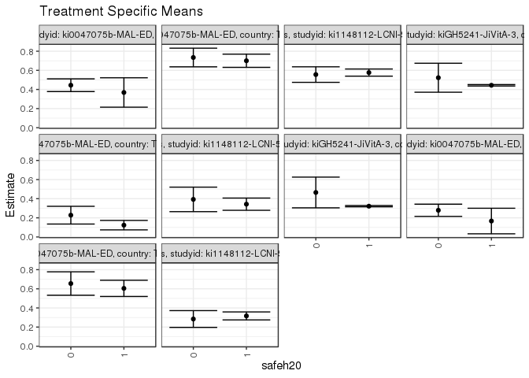

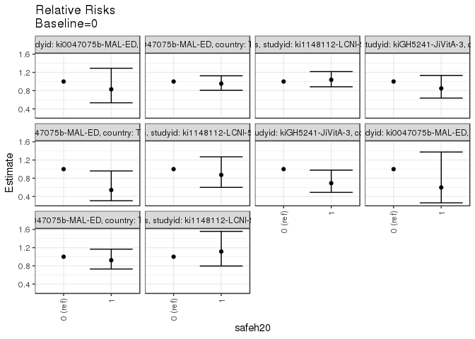

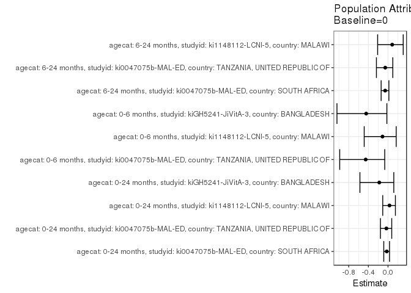

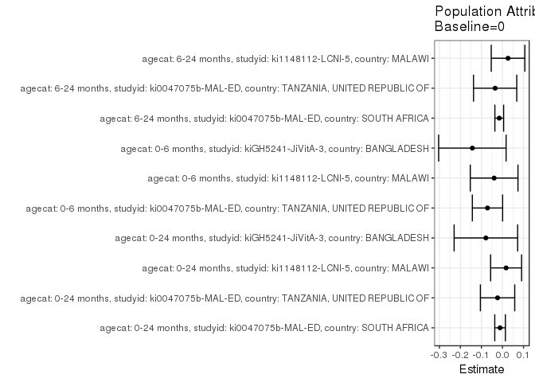

## Results Table

### Parameter: TSM

| agecat | studyid | country | intervention_level | baseline_level | estimate | ci_lower | ci_upper |
| --- | --- | --- | --- | --- | --- | --- | --- |
| 0-24 months | ki0047075b-MAL-ED | SOUTH AFRICA | 0 | NA | 0.4444444 | 0.3780472 | 0.5108417 |
| 0-24 months | ki0047075b-MAL-ED | SOUTH AFRICA | 1 | NA | 0.3684211 | 0.2147476 | 0.5220945 |
| 0-24 months | ki0047075b-MAL-ED | TANZANIA, UNITED REPUBLIC OF | 0 | NA | 0.7341772 | 0.6365648 | 0.8317896 |
| 0-24 months | ki0047075b-MAL-ED | TANZANIA, UNITED REPUBLIC OF | 1 | NA | 0.7000000 | 0.6309749 | 0.7690251 |
| 0-24 months | ki1148112-LCNI-5 | MALAWI | 0 | NA | 0.5555556 | 0.4743463 | 0.6367648 |
| 0-24 months | ki1148112-LCNI-5 | MALAWI | 1 | NA | 0.5765230 | 0.5391697 | 0.6138764 |
| 0-24 months | kiGH5241-JiVitA-3 | BANGLADESH | 0 | NA | 0.5227273 | 0.3712133 | 0.6742412 |
| 0-24 months | kiGH5241-JiVitA-3 | BANGLADESH | 1 | NA | 0.4437164 | 0.4362005 | 0.4512324 |
| 0-6 months | ki0047075b-MAL-ED | TANZANIA, UNITED REPUBLIC OF | 0 | NA | 0.2278481 | 0.1351689 | 0.3205273 |
| 0-6 months | ki0047075b-MAL-ED | TANZANIA, UNITED REPUBLIC OF | 1 | NA | 0.1235294 | 0.0739671 | 0.1730917 |
| 0-6 months | ki1148112-LCNI-5 | MALAWI | 0 | NA | 0.3928571 | 0.2647051 | 0.5210092 |
| 0-6 months | ki1148112-LCNI-5 | MALAWI | 1 | NA | 0.3427230 | 0.2788654 | 0.4065806 |
| 0-6 months | kiGH5241-JiVitA-3 | BANGLADESH | 0 | NA | 0.4651163 | 0.3043983 | 0.6258342 |
| 0-6 months | kiGH5241-JiVitA-3 | BANGLADESH | 1 | NA | 0.3217224 | 0.3149667 | 0.3284782 |
| 6-24 months | ki0047075b-MAL-ED | SOUTH AFRICA | 0 | NA | 0.2789474 | 0.2150320 | 0.3428627 |
| 6-24 months | ki0047075b-MAL-ED | SOUTH AFRICA | 1 | NA | 0.1666667 | 0.0330039 | 0.3003294 |
| 6-24 months | ki0047075b-MAL-ED | TANZANIA, UNITED REPUBLIC OF | 0 | NA | 0.6551724 | 0.5325197 | 0.7778251 |
| 6-24 months | ki0047075b-MAL-ED | TANZANIA, UNITED REPUBLIC OF | 1 | NA | 0.6046512 | 0.5200531 | 0.6892492 |
| 6-24 months | ki1148112-LCNI-5 | MALAWI | 0 | NA | 0.2843137 | 0.1966977 | 0.3719298 |
| 6-24 months | ki1148112-LCNI-5 | MALAWI | 1 | NA | 0.3165618 | 0.2747843 | 0.3583394 |

### Parameter: E(Y)

| agecat | studyid | country | intervention_level | baseline_level | estimate | ci_lower | ci_upper |
| --- | --- | --- | --- | --- | --- | --- | --- |
| 0-24 months | ki0047075b-MAL-ED | SOUTH AFRICA | NA | NA | 0.4330709 | 0.3720144 | 0.4941273 |
| 0-24 months | ki0047075b-MAL-ED | TANZANIA, UNITED REPUBLIC OF | NA | NA | 0.7108434 | 0.6544178 | 0.7672689 |
| 0-24 months | ki1148112-LCNI-5 | MALAWI | NA | NA | 0.5728274 | 0.5388870 | 0.6067678 |
| 0-24 months | kiGH5241-JiVitA-3 | BANGLADESH | NA | NA | 0.4438442 | 0.4363209 | 0.4513674 |
| 0-6 months | ki0047075b-MAL-ED | TANZANIA, UNITED REPUBLIC OF | NA | NA | 0.1566265 | 0.1113925 | 0.2018605 |
| 0-6 months | ki1148112-LCNI-5 | MALAWI | NA | NA | 0.3531599 | 0.2959376 | 0.4103821 |
| 0-6 months | kiGH5241-JiVitA-3 | BANGLADESH | NA | NA | 0.3219496 | 0.3151876 | 0.3287116 |
| 6-24 months | ki0047075b-MAL-ED | SOUTH AFRICA | NA | NA | 0.2636364 | 0.2052818 | 0.3219909 |
| 6-24 months | ki0047075b-MAL-ED | TANZANIA, UNITED REPUBLIC OF | NA | NA | 0.6203209 | 0.5505766 | 0.6900651 |
| 6-24 months | ki1148112-LCNI-5 | MALAWI | NA | NA | 0.3108808 | 0.2731472 | 0.3486144 |

### Parameter: RR

| agecat | studyid | country | intervention_level | baseline_level | estimate | ci_lower | ci_upper |
| --- | --- | --- | --- | --- | --- | --- | --- |
| 0-24 months | ki0047075b-MAL-ED | SOUTH AFRICA | 0 | 0 | 1.0000000 | 1.0000000 | 1.0000000 |
| 0-24 months | ki0047075b-MAL-ED | SOUTH AFRICA | 1 | 0 | 0.8289474 | 0.5322410 | 1.2910575 |
| 0-24 months | ki0047075b-MAL-ED | TANZANIA, UNITED REPUBLIC OF | 0 | 0 | 1.0000000 | 1.0000000 | 1.0000000 |
| 0-24 months | ki0047075b-MAL-ED | TANZANIA, UNITED REPUBLIC OF | 1 | 0 | 0.9534483 | 0.8079940 | 1.1250871 |
| 0-24 months | ki1148112-LCNI-5 | MALAWI | 0 | 0 | 1.0000000 | 1.0000000 | 1.0000000 |
| 0-24 months | ki1148112-LCNI-5 | MALAWI | 1 | 0 | 1.0377415 | 0.8844005 | 1.2176693 |
| 0-24 months | kiGH5241-JiVitA-3 | BANGLADESH | 0 | 0 | 1.0000000 | 1.0000000 | 1.0000000 |
| 0-24 months | kiGH5241-JiVitA-3 | BANGLADESH | 1 | 0 | 0.8488488 | 0.6355799 | 1.1336800 |
| 0-6 months | ki0047075b-MAL-ED | TANZANIA, UNITED REPUBLIC OF | 0 | 0 | 1.0000000 | 1.0000000 | 1.0000000 |
| 0-6 months | ki0047075b-MAL-ED | TANZANIA, UNITED REPUBLIC OF | 1 | 0 | 0.5421569 | 0.3061930 | 0.9599633 |
| 0-6 months | ki1148112-LCNI-5 | MALAWI | 0 | 0 | 1.0000000 | 1.0000000 | 1.0000000 |
| 0-6 months | ki1148112-LCNI-5 | MALAWI | 1 | 0 | 0.8723858 | 0.5991809 | 1.2701624 |
| 0-6 months | kiGH5241-JiVitA-3 | BANGLADESH | 0 | 0 | 1.0000000 | 1.0000000 | 1.0000000 |
| 0-6 months | kiGH5241-JiVitA-3 | BANGLADESH | 1 | 0 | 0.6917033 | 0.4895856 | 0.9772620 |
| 6-24 months | ki0047075b-MAL-ED | SOUTH AFRICA | 0 | 0 | 1.0000000 | 1.0000000 | 1.0000000 |
| 6-24 months | ki0047075b-MAL-ED | SOUTH AFRICA | 1 | 0 | 0.5974843 | 0.2594752 | 1.3758056 |
| 6-24 months | ki0047075b-MAL-ED | TANZANIA, UNITED REPUBLIC OF | 0 | 0 | 1.0000000 | 1.0000000 | 1.0000000 |
| 6-24 months | ki0047075b-MAL-ED | TANZANIA, UNITED REPUBLIC OF | 1 | 0 | 0.9228886 | 0.7305484 | 1.1658685 |
| 6-24 months | ki1148112-LCNI-5 | MALAWI | 0 | 0 | 1.0000000 | 1.0000000 | 1.0000000 |
| 6-24 months | ki1148112-LCNI-5 | MALAWI | 1 | 0 | 1.1134244 | 0.7962865 | 1.5568693 |

### Parameter: PAR

| agecat | studyid | country | intervention_level | baseline_level | estimate | ci_lower | ci_upper |
| --- | --- | --- | --- | --- | --- | --- | --- |
| 0-24 months | ki0047075b-MAL-ED | SOUTH AFRICA | 0 | NA | -0.0113736 | -0.0366402 | 0.0138930 |
| 0-24 months | ki0047075b-MAL-ED | TANZANIA, UNITED REPUBLIC OF | 0 | NA | -0.0233338 | -0.1049796 | 0.0583119 |
| 0-24 months | ki1148112-LCNI-5 | MALAWI | 0 | NA | 0.0172719 | -0.0563631 | 0.0909068 |
| 0-24 months | kiGH5241-JiVitA-3 | BANGLADESH | 0 | NA | -0.0788831 | -0.2298980 | 0.0721318 |
| 0-6 months | ki0047075b-MAL-ED | TANZANIA, UNITED REPUBLIC OF | 0 | NA | -0.0712216 | -0.1432301 | 0.0007869 |
| 0-6 months | ki1148112-LCNI-5 | MALAWI | 0 | NA | -0.0396973 | -0.1530971 | 0.0737026 |
| 0-6 months | kiGH5241-JiVitA-3 | BANGLADESH | 0 | NA | -0.1431667 | -0.3035956 | 0.0172622 |
| 6-24 months | ki0047075b-MAL-ED | SOUTH AFRICA | 0 | NA | -0.0153110 | -0.0361490 | 0.0055270 |
| 6-24 months | ki0047075b-MAL-ED | TANZANIA, UNITED REPUBLIC OF | 0 | NA | -0.0348516 | -0.1376914 | 0.0679883 |
| 6-24 months | ki1148112-LCNI-5 | MALAWI | 0 | NA | 0.0265671 | -0.0534060 | 0.1065402 |

### Parameter: PAF

| agecat | studyid | country | intervention_level | baseline_level | estimate | ci_lower | ci_upper |
| --- | --- | --- | --- | --- | --- | --- | --- |
| 0-24 months | ki0047075b-MAL-ED | SOUTH AFRICA | 0 | NA | -0.0262626 | -0.0863664 | 0.0305159 |
| 0-24 months | ki0047075b-MAL-ED | TANZANIA, UNITED REPUBLIC OF | 0 | NA | -0.0328256 | -0.1544478 | 0.0759836 |
| 0-24 months | ki1148112-LCNI-5 | MALAWI | 0 | NA | 0.0301519 | -0.1073254 | 0.1505611 |
| 0-24 months | kiGH5241-JiVitA-3 | BANGLADESH | 0 | NA | -0.1777270 | -0.5720641 | 0.1176944 |
| 0-6 months | ki0047075b-MAL-ED | TANZANIA, UNITED REPUBLIC OF | 0 | NA | -0.4547225 | -0.9835123 | -0.0669041 |
| 0-6 months | ki1148112-LCNI-5 | MALAWI | 0 | NA | -0.1124060 | -0.4847985 | 0.1665892 |
| 0-6 months | kiGH5241-JiVitA-3 | BANGLADESH | 0 | NA | -0.4446866 | -1.0395612 | -0.0233179 |
| 6-24 months | ki0047075b-MAL-ED | SOUTH AFRICA | 0 | NA | -0.0580762 | -0.1398706 | 0.0178488 |
| 6-24 months | ki0047075b-MAL-ED | TANZANIA, UNITED REPUBLIC OF | 0 | NA | -0.0561831 | -0.2360325 | 0.0974972 |
| 6-24 months | ki1148112-LCNI-5 | MALAWI | 0 | NA | 0.0854575 | -0.2115656 | 0.3096635 |